# BCB420 Assignment 1

Isabel Li

2024-02-13

Citation (packages): [1], [2], [3], [4], [5]

# Installation of necessary packages:

```r
if (!requireNamespace("BiocManager", quietly = TRUE))
    install.packages("BiocManager")

if(!requireNamespace("GEOquery", quietly = TRUE))
    BiocManager::install("GEOquery")
if(!requireNamespace("limma", quietly = TRUE))
    BiocManager::install("limma")

if(!requireNamespace("kableExtra", quietly = TRUE))
  install.packages("kableExtra")

if(!requireNamespace('dplyr', quietly = TRUE))
  tidyr::install("dplyr")

if(!requireNamespace('edgeR', quietly = TRUE))
  install.packages('edgeR')

if(!requireNamespace('htmltools', quietly = TRUE))
  install.packages('htmltools')

library(GEOquery)
```

```r
library(limma)
library(biomaRt)
library(knitr)
library(kableExtra)
library(dplyr)
library(edgeR)
library(ggplot2)
library(htmltools)
```

# Introduction to dataset

The dataset[6] I will be focusing on is on adult-onset Still’s disease (AOSD) which is a rare autoinflammatory disease. The most serious symptom resulting from AOSD is macrophage activation syndrome (MAS). To date, there is limited research on AOSD patients with MAS and biomarkers that could be used to detect it. Thus, the study[7] aims to contribute to this research area. In this assignment I will be cleaning the dataset containing healthy patient (HC), AOSD patients with MAS (AOSD-MAS) and AOSD patient with no MAS (AOSD).

# 1. Retrieving information from the chosen dataset

The dataset chosen for this assignment is GSE247993

```r
dataset_geoid <- "GSE247993"

gse <- getGEO(dataset_geoid, GSEMatrix = FALSE) #download and parse information available from NCBI GEO associated with the chosen dataaset
gse@header$summary
```

```
## [1] "Adult-onset Still’s disease (AOSD) is a rare autoinflammatory disease, characterized by fever, rash, arthritis and other systemic inflammatory manifestations like hepatosplenomegaly and serositis. One of the most serious complications AOSD is macrophage activation syndrome (MAS), a life-thre…
```

Information about Platform:

```r
current_gpl <- names(GPLList(gse))[1]
current_gpl_info <- Meta(getGEO(current_gpl)) #Grab metadata of platform
```

```r
#Grab attributes of the platform used
platform_title <- current_gpl_info$title
submission_date <- current_gpl_info$submission_date
last_update_date <- current_gpl_info$last_update_date
organism <- current_gpl_info$organism
```

**Platform title:** BGISEQ-500 (Homo sapiens)

**Submission date:** Mar 24 2017

**Last update date:** Jan 07 2019

**Organism:** Homo sapiens

```r
gse@gsms[[1]]@header$data_processing
```

```
## [1] "The sequencing data was filtered with SOAPnuke (v1.5.2)  by (1) Removing reads containing sequencing adapter; (2) Removing reads whose low-quality base ratio (base quality less than or equal to 5) is more than 20%; (3) Removing reads whose unknown base ('N' base) ratio is more than 5%, after…
## [2] "The clean reads were mapped to the reference genome using HISAT2 (v2.0.4)"
## [3] "Bowtie2 (v2.2.5) was applied to align the clean reads to the reference coding gene set, then expression level of gene was calculated by RSEM (v1.2.12)"
## [4] "Differentially expressed genes (DEGs) with a fold change >2 and p value< 0.05 were determined using DEGseq analysis package"
## [5] "Assembly: Genome Reference Consortium Human Build 38 patch release 12 (GRCh38.p12)"
## [6] "Supplementary files format and content: text files include read count values for each Sample"
```

It is important to note that the RNASeq data is gene level data produced from RSEM

Get the expression data file info:

```r
sfilenames = getGEOSuppFiles(dataset_geoid, fetch_files = FALSE)
sfilenames$fname
```

```
## [1] "GSE247993_processed_data_file.txt.gz"
```

```r
data_filename <- sfilenames$fname[1]
```

```r
#location to download and store files
download_dir <- file.path(getwd())
```

```r
missing_files <- sfilenames$fname[!unlist(lapply(sfilenames$fname, FUN=function(x){
  file.exists(file.path(download_dir, dataset_geoid,x))}))]

if (length(missing_files >0)){
  sfiles = getGEOSuppFiles(dataset_geoid, filter_regex = data_filename,
                           baseDir = download_dir, fetch_files = TRUE)
  }
```

```r
counts_data <- read.table(
  file.path(download_dir, dataset_geoid, data_filename),
  header=TRUE,
  check.names=TRUE)

dim(counts_data) #looking at number of genes, number of samples
```

```
## [1] 16684    25
```

```r
kbl(counts_data[1:5, 1:25]) %>% kable_styling(latex_options = "scale_down", position = 'center') #check to see if table looks okay
```

| st_gene_id | gene_id | gene_symbol | read_count_HC_1 | read_count_HC_2 | read_count_HC_3 | read_count_HC_4 | read_count_HC_5 | read_count_HC_6 | read_count_HC_7 | read_count_HC_8 | read_count_HC_9 | read_count_HC_10 | read_count_Patient_1 | read_count_Patient_2 | read_count_Patient_3 | read_count_Patient_4 | read_count_Patient_5 | read_count_Patient_6 | read_count_Patient_7 | read_count_Patient_8 | read_count_Patient_9 | read_count_Patient_10 | read_count_Patient_11 | read_count_Patient_12 |
| --- | --- | --- | --- | --- | --- | --- | --- | --- | --- | --- | --- | --- | --- | --- | --- | --- | --- | --- | --- | --- | --- | --- | --- | --- |
| G9606_9266 | 2323 | FLT3LG | 419.2 | 493.45 | 434.23 | 1024.60 | 587.05 | 615.29 | 149.35 | 156.37 | 235.86 | 420.93 | 281.60 | 505.59 | 315.95 | 465.40 | 282.91 | 546.13 | 360.75 | 255.84 | 384.82 | 292.20 | 376.29 | 356.21 |
| G9606_9392 | 90459 | ERI1 | 273.2 | 260.28 | 259.10 | 262.11 | 239.73 | 253.36 | 180.59 | 191.55 | 214.08 | 211.48 | 695.98 | 283.18 | 520.88 | 241.05 | 220.07 | 556.23 | 267.72 | 319.72 | 444.95 | 386.01 | 183.95 | 334.25 |
| G9606_4009 | 79595 | SAP130 | 685.0 | 652.00 | 653.00 | 699.00 | 656.00 | 820.00 | 690.00 | 751.00 | 825.00 | 616.00 | 860.00 | 798.00 | 633.00 | 860.00 | 564.00 | 878.00 | 646.00 | 700.00 | 558.00 | 979.00 | 635.00 | 588.00 |
| G9606_4181 | 10927 | SPIN1 | 552.0 | 558.00 | 601.00 | 677.00 | 554.00 | 631.00 | 580.00 | 482.00 | 560.00 | 580.00 | 537.00 | 430.00 | 480.00 | 507.00 | 314.00 | 555.00 | 431.00 | 381.00 | 463.00 | 459.00 | 459.00 | 427.00 |
| G9606_32562 | 7475 | WNT6 | 6.0 | 13.00 | 6.00 | 7.00 | 4.00 | 5.00 | 1.00 | 4.00 | 10.00 | 4.00 | 13.00 | 7.00 | 18.00 | 9.00 | 3.00 | 5.00 | 0.00 | 6.00 | 5.00 | 4.00 | 13.00 | 10.00 |

```r
for (i in 1:length(gse@gsms)){
  x <- gse@gsms[[i]]@header$characteristics_ch1
  print(x)
} #Look to see what the sample conditions are
```

```
## [1] "cell type: Monocytes"           "disease state: healthy control"
## [1] "cell type: Monocytes"           "disease state: healthy control"
## [1] "cell type: Monocytes"           "disease state: healthy control"
## [1] "cell type: Monocytes"           "disease state: healthy control"
## [1] "cell type: Monocytes"           "disease state: healthy control"
## [1] "cell type: Monocytes"           "disease state: healthy control"
## [1] "cell type: Monocytes"           "disease state: healthy control"
## [1] "cell type: Monocytes"           "disease state: healthy control"
## [1] "cell type: Monocytes"           "disease state: healthy control"
## [1] "cell type: Monocytes"           "disease state: healthy control"
## [1] "cell type: Monocytes"      "disease state: naïve AOSD"
## [1] "cell type: Monocytes"      "disease state: naïve AOSD"
## [1] "cell type: Monocytes"      "disease state: naïve AOSD"
## [1] "cell type: Monocytes"      "disease state: naïve AOSD"
## [1] "cell type: Monocytes"      "disease state: naïve AOSD"
## [1] "cell type: Monocytes"      "disease state: naïve AOSD"
## [1] "cell type: Monocytes"      "disease state: naïve AOSD"
## [1] "cell type: Monocytes"      "disease state: naïve AOSD"
## [1] "cell type: Monocytes"      "disease state: naïve AOSD"
## [1] "cell type: Monocytes"      "disease state: naïve AOSD"
## [1] "cell type: Monocytes"      "disease state: naïve AOSD"
## [1] "cell type: Monocytes"      "disease state: naïve AOSD"
```

Other info about experiment

```r
gse@header$sample_id
```

```
##  [1] "GSM7904204" "GSM7904205" "GSM7904206" "GSM7904207" "GSM7904208"
##  [6] "GSM7904209" "GSM7904210" "GSM7904211" "GSM7904212" "GSM7904213"
## [11] "GSM7904214" "GSM7904215" "GSM7904216" "GSM7904217" "GSM7904218"
## [16] "GSM7904219" "GSM7904220" "GSM7904221" "GSM7904222" "GSM7904223"
## [21] "GSM7904224" "GSM7904225"
```

## 2.1 Assess data quality for the control and test conditions in dataset

Check if there are no missing values in ‘counts_data’

```r
anyMissing(counts_data)
```

```
## [1] FALSE
```

The result ‘FALSE’ tell us that there are no missing values in ‘counts_data’

Lets make sure that there were not any duplicate gene names and gene symbols

```r
length(unique(counts_data[,'st_gene_id'])) == length(counts_data[,'st_gene_id']) # check that number of unique gene names in rownames == number of rows
```

```
## [1] TRUE
```

```r
length(unique(counts_data[,'gene_id'])) == length(counts_data[,'gene_id'])
```

```
## [1] TRUE
```

```r
length(unique(counts_data[,'gene_symbol'])) == length(counts_data[,'gene_symbol'])
```

```
## [1] TRUE
```

The above results shows that there are no empty values nor duplicate genes

## 2.2 Mapping entrez id to HUGO symbols

I will be using the ‘gene_id’ row which represents NCBI Gene ID (Entrez ID) to map to HUGO symbols.

```r
ensembl <- useMart("ensembl") #connect to desired mart
datasets <- listDatasets(ensembl)
kable(head(datasets[grep(datasets$dataset, pattern = 'sapiens'),]), format = 'html') %>% kable_styling(latex_options = "scale_down", position = 'center')
```

|  | dataset | description | version |
| --- | --- | --- | --- |
| 80 | hsapiens_gene_ensembl | Human genes (GRCh38.p14) | GRCh38.p14 |

From the above result, I know to use the ‘hsapiens_gene_ensembl’ dataset. So let’s store it in a variable.

```r
ensembl <- useDataset("hsapiens_gene_ensembl", mart=ensembl)
```

Next, I need to find out what to parse through the filter.

```r
#To find what to parse through filter
biomart_human_filters <- listFilters(ensembl)
kable(biomart_human_filters[grep(biomart_human_filters$name, pattern = 'entrez')
                            ,], format = 'html') %>% kable_styling(latex_options = "scale_down", position = 'center')
```

|  | name | description |
| --- | --- | --- |
| 15 | with_entrezgene_trans_name | With EntrezGene transcript name ID(s) |
| 31 | with_entrezgene | With NCBI gene (formerly Entrezgene) ID(s) |
| 70 | entrezgene_trans_name | EntrezGene transcript name ID(s) [e.g. A2MP1-202] |
| 89 | entrezgene_accession | NCBI gene (formerly Entrezgene) accession(s) [e.g. A1BG] |
| 90 | entrezgene_id | NCBI gene (formerly Entrezgene) ID(s) [e.g. 1] |

So the filter is ‘entrezgene_id’. Next, find out what is the ‘name’ to parse through attributes:

```r
#to find what is the name to parse through attributes
kable(searchAttributes(mart = ensembl, 'hgnc|entrez'), format = 'html') %>% kable_styling(latex_options = "scale_down", position = 'center')
```

|  | name | description | page |
| --- | --- | --- | --- |
| 58 | entrezgene_trans_name | EntrezGene transcript name ID | feature_page |
| 62 | hgnc_id | HGNC ID | feature_page |
| 63 | hgnc_symbol | HGNC symbol | feature_page |
| 77 | entrezgene_description | NCBI gene (formerly Entrezgene) description | feature_page |
| 78 | entrezgene_accession | NCBI gene (formerly Entrezgene) accession | feature_page |
| 79 | entrezgene_id | NCBI gene (formerly Entrezgene) ID | feature_page |
| 93 | hgnc_trans_name | Transcript name ID | feature_page |

Thus, I will be parsing ‘hgnc_symbol’ and ‘entrezgene_id’ into attributes. Finally, we can use what we have found out above to map the entrez ids to hugo symbols:

```r
# Mapping the entrez ids to hugo symbols
entrez_id <- counts_data[,'gene_id']
id_mapped <- getBM(attributes = c("entrezgene_id", "hgnc_symbol"),
                   filters = c("entrezgene_id"),
                   values = entrez_id,
                   mart = ensembl)
```

## 2.3 Quality check the mapping

```r
id_mapped <- as.data.frame(id_mapped) # convert id_mapped to dataframe
id_mapped[id_mapped==""]<-NA # change all empty strings "" to NA, so that we can filter for empty cells in the dataframe
```

```r
length(counts_data[,'gene_id']) # how many rows are there in counts_data
```

```
## [1] 16684
```

```r
nrow(id_mapped) # number of rows in id_mapped
```

```
## [1] 16448
```

```r
sum(is.na(id_mapped[,1])) #number of empty entries in id_mapped entrez gene id column
```

```
## [1] 0
```

```r
sum(is.na(id_mapped[,2])) #number of empty entries in id_mapped
```

```
## [1] 105
```

How many genes were mapped?

```r
length(unique(id_mapped$entrezgene_id))
```

```
## [1] 16349
```

We were able to map 16349 genes. But how many genes were not mapped

```r
length(counts_data[,'gene_id']) - length(unique(id_mapped$entrezgene_id))
```

```
## [1] 335
```

Check if mapping between entrez_id and hgnc_symbol is one-to-one:

Are there any duplicated id_mapped[,‘entrezgene_id’]?

```r
dup_entrez = nrow(id_mapped[duplicated(id_mapped[,'entrezgene_id']),]) #number of duplicated entrezid
dup_entrez
```

```
## [1] 99
```

Let’s remove duplicate valued from id_mapped.

```r
id_mapped <- id_mapped %>% dplyr::distinct(entrezgene_id, .keep_all = TRUE) #remove duplicate rows based on entrezgene_id
length(unique(id_mapped$entrezgene_id))
```

```
## [1] 16349
```

Are there any duplicated id_mapped[,hgnc_symbol]?

First, lets remove rows with empty values in hgnc_symbol column.

```r
id_mapped <- id_mapped[-which(is.na(id_mapped$hgnc_symbol)), ] #remove rows where there is NA in hgnc_symbol
length(which(is.na(id_mapped$hgnc_symbol) == TRUE))
```

```
## [1] 0
```

Now, we can see if there are any duplicated hgnc_symbols

```r
length(unique(id_mapped$hgnc_symbol))
```

```
## [1] 16209
```

```r
length(id_mapped$hgnc_symbol)
```

```
## [1] 16262
```

```r
#check for duplicate values in counts_data
dup_hgnc = which(duplicated(id_mapped$hgnc_symbol))
dup_hgnc
```

```
##  [1]    68  1719  2132  2849  2907  2993  4189  4327  4340  4741  4859  6237
## [13]  6716  7021  7245  7575  8249  8252  8406  8434  8808  9031  9971 10089
## [25] 11137 11159 11383 11625 11658 12247 12266 12280 12321 12322 12324 12325
## [37] 12425 12474 12495 13183 13426 13534 13957 14095 14153 14235 14294 14610
## [49] 15353 15357 15371 15568 15761
```

```r
length(dup_hgnc)
```

```
## [1] 53
```

## Combine the mapped ids into counts_data

```r
# add columns to counts_data with entrez_id and hgnc identifier
counts_data[,'entrez_id'] = NA
counts_data[, 'hgnc_symbol'] = NA
counts_data = data.frame(counts_data)
counts_data = counts_data %>% relocate('entrez_id', 'hgnc_symbol') # move the entrez_id and hgnc_symbol to the front
```

```r
# fill in the counts_data with the mapped ids
for (i in 1:nrow(counts_data)){
  indx = which(id_mapped[,'entrezgene_id'] == counts_data[i,'gene_id'],
                  arr.ind = TRUE)
  if (length(indx) >0){
    #if the entrezgene_id was mapped to a hgnc symbol, add it to counts_data
    counts_data[i, 'entrez_id'] = id_mapped[indx[1], 'entrezgene_id']
    counts_data[i, 'hgnc_symbol'] = id_mapped[indx[1], 'hgnc_symbol']
  }
}
```

```r
missing <- kable(counts_data[
  which(is.na(counts_data$hgnc_symbol))[1:5],1:5], type="html")
missing
```

|  | entrez_id | hgnc_symbol | st_gene_id | gene_id | gene_symbol |
| --- | --- | --- | --- | --- | --- |
| 28 | NA | NA | G9606_26136 | 23520 | ANP32C |
| 57 | NA | NA | G9606_33917 | 107984751 | LOC107984751 |
| 117 | NA | NA | G9606_8605 | 107984974 | LOC107984974 |
| 177 | NA | NA | G9606_21513 | 105377805 | LOC105377805 |
| 183 | NA | NA | G9606_21026 | 107984138 | LOC107984138 |

Upon manually searching the values from ‘gene_id’ in the ‘missing’ table, which is a table of unmapped entrez_id, I found that there were no HUGO symbols associated with them.

# Distribution of dataset

## Boxplot of RNA-seq data before normalization

First, we can make a function to generate a boxplot of the data

```r
# create function to generate boxplot of RNASeq data
boxplot_rnaseq <- function(count_data, title){
  log2_data <- log2(count_data)

  boxplot(log2_data,xlab = "Samples", ylab = "log2 TPM", las = 2, cex = 0.5,
        cex.lab = 0.5, cex.axis = 0.5, main = title)

  abline(h = median(apply(log2_data, 2, median)),
       col = "green", lwd = 0.6, lty = "dashed")
}
```

Below is a boxplot of RNASeq data before normalization

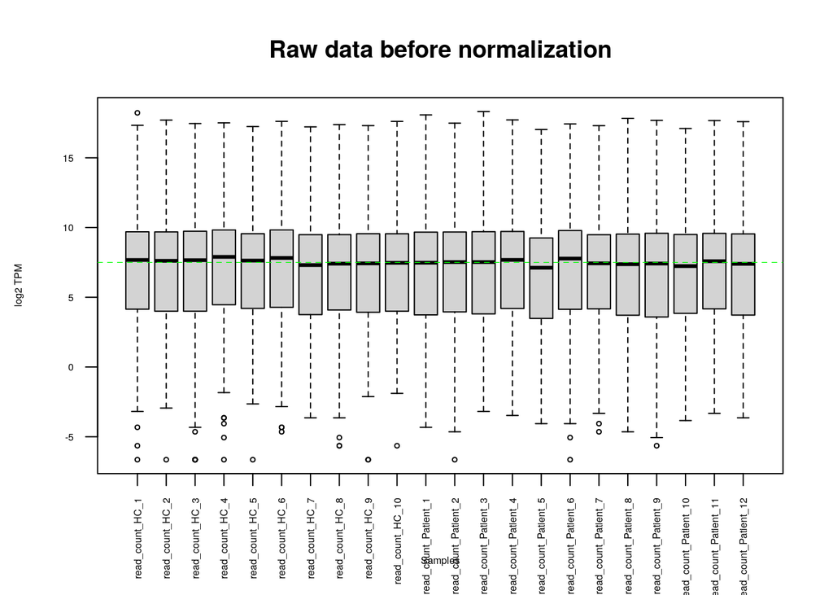

Boxplot of raw data before normalization

```r
boxplot_rnaseq(counts_data[,6:27], 'Raw data before normalization')
```

## Density plot of RNASeq data before normalization

First, we can make a function to generate density plots

```r
# function to make density plot
density_plot <- function(count_data, title){
  counts_density <- apply(log2(count_data),2, density)
  xlim <- 0; ylim <- 0
  for (i in 1:length(counts_density)){
    xlim <- range(c(xlim, counts_density[[i]]$x));
    ylim <- range(c(ylim, counts_density[[i]]$y))}

  cols <- rainbow(length(counts_density))
  ltys <- rep(1, length(counts_density))

  #plot the first density plot to initialize plot
  plot(counts_density[[1]], xlim=xlim, ylim=ylim, type="n",
       ylab="Smoothing density of log2-CPM", main="", cex.lab = 0.85)

  #plot each line
  for (i in 1:length(counts_density)){
    lines(counts_density[[i]], col=cols[i], lty=ltys[i])
  }
  title(title)

}
```

Below is a plot of raw count_data before normalization

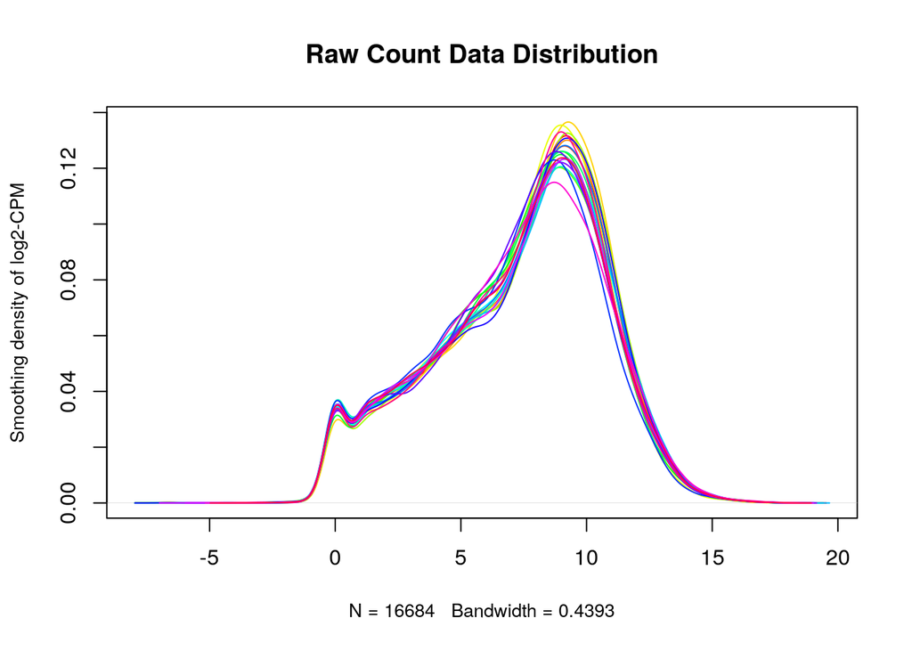

Density plot of raw data

```r
density_plot(counts_data[,6:27], 'Raw Count Data Distribution')
```

# Normalization

## Removing outliers - Filter out low counts

Lowly expressed genes are often background noise rather than a meaningful biological signal. edgeR recommends that the genes are filtered out if they can’t be expressed in all of the samples for any of the conditions.

```r
min_samp <- 11 # number of samples in healthy control is 10 and number of samples in AOSD is 12. So I'm going to choose a number in between as the minimum number of samples

count_mat <- as.matrix(counts_data[,6:27])
#get rid of low counts
keep = rowSums(cpm(count_mat) >1) > min_samp # keep genes that have at least 1
# count per million and that they are found in at least 11 samples

filtered_count_mat = counts_data[keep,] #filter the dataset to values that meet the 'keep' condition
```

How many low counts were filtered out?

```r
nrow(filtered_count_mat)
```

```
## [1] 12404
```

```r
nrow(counts_data) - nrow(filtered_count_mat)
```

```
## [1] 4280
```

12404 were kept and 4280 were removed from the count data

```r
(nrow(filtered_count_mat))/nrow(counts_data) *100
```

```
## [1] 74.34668
```

74% of the data survived low read count filter

```r
# check if saved file exists
if (file.exists(file.path(download_dir,"filtered_count_mat.RData"))==FALSE){
  save(filtered_count_mat, file = "filtered_count_mat.RData")
}
```

Now let’s see how filtering changed the data

```r
boxplot_rnaseq(counts_data[,6:27], 'Raw Count data')
```

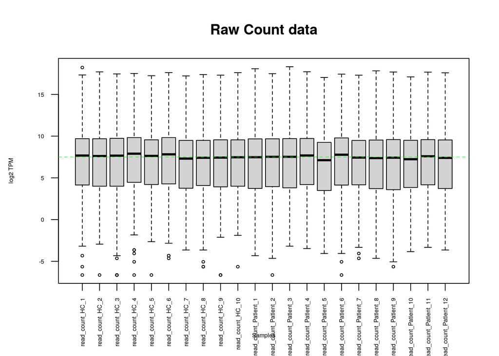

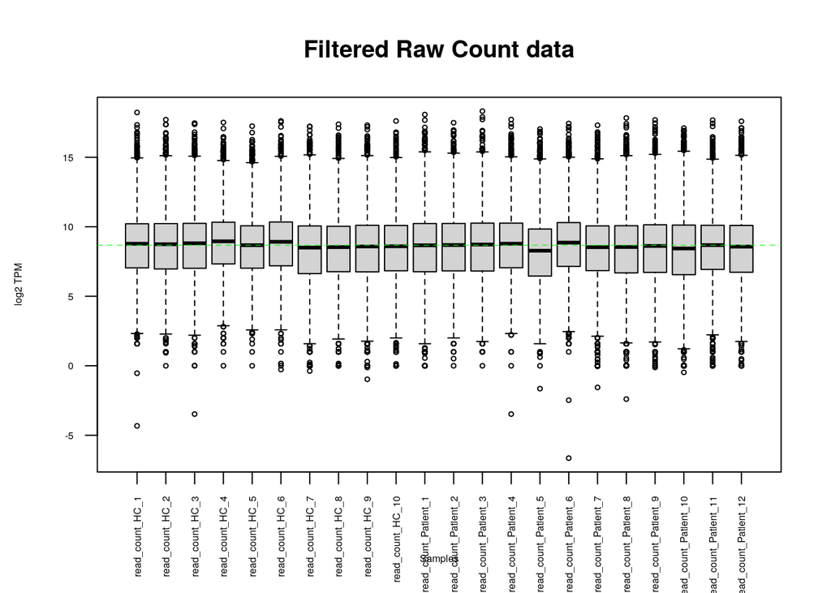

Boxplot comparison of raw data and filtered raw data

```r
boxplot_rnaseq(filtered_count_mat[,6:27], 'Filtered Raw Count data')
```

```r
density_plot(counts_data[,6:27], 'Raw Count data')
```

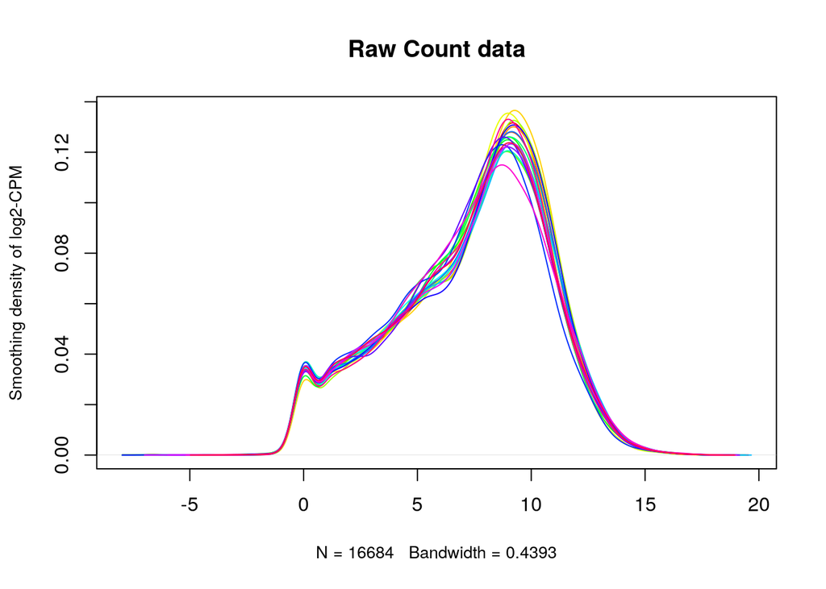

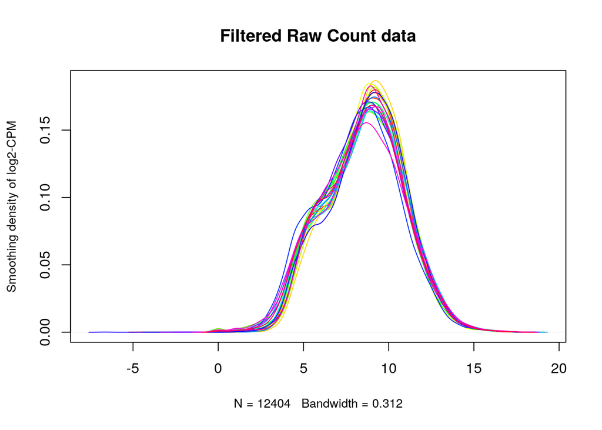

Density plots of raw data and filtered raw data

```r
density_plot(filtered_count_mat[,6:27], 'Filtered Raw Count data')
```

## Applying TMM to the dataset

```r
#Create an edgeR container for RNASeq count data
conditions = c(rep("Healthy Control",10),rep("AOSD-MAS",9),rep("AOSD",3))
TMM = DGEList(counts = filtered_count_mat, group=conditions) # set group to conditions so DGE can calculate means across groups
```

```
## Non-numeric columns found: setting first 5 columns of `counts` to be gene annotation.
```

```r
d = calcNormFactors(TMM) #calculate normalization factors
TMM_norm_counts <- cpm(TMM)
```

```r
if (file.exists(file.path(download_dir,"TMM.RData"))==FALSE){
  save(TMM, file = 'TMM.RData')
}
if (file.exists(file.path(download_dir,"TMM_norm_counts.RData"))==FALSE){
  save(TMM_norm_counts, file = 'TMM_norm_counts.RData')
}
```

## Comparing normalized data to original data

Let’s see how the boxplot of rnaseq data changes

```r
boxplot_rnaseq(counts_data[,6:27], 'Raw Count data')
```

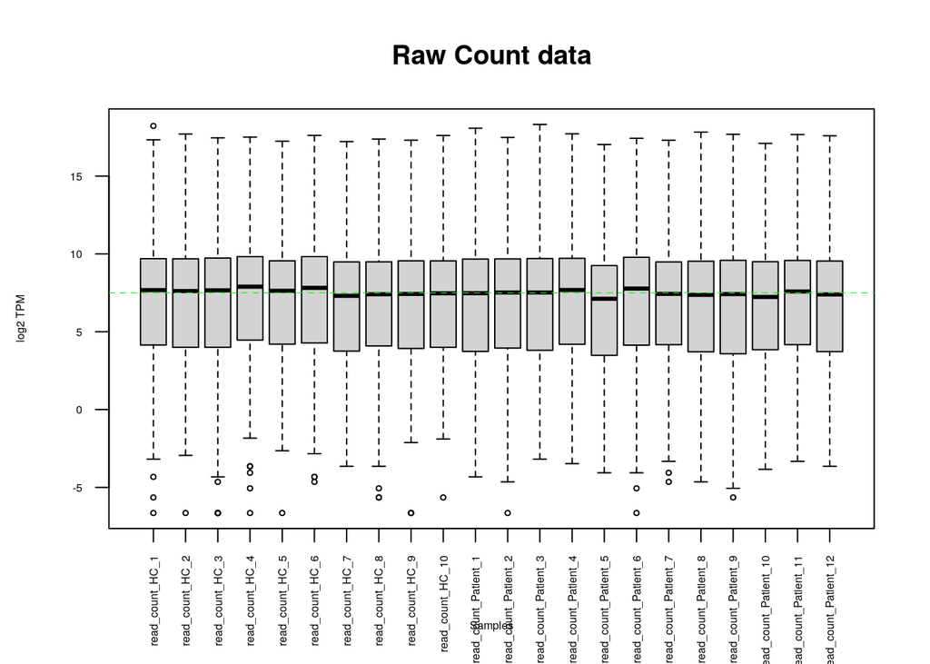

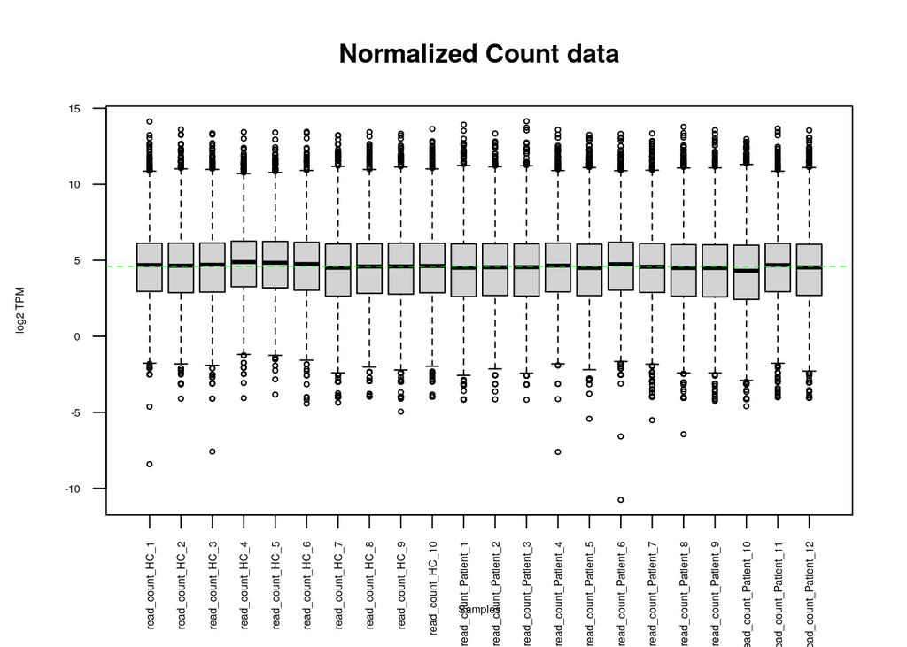

Boxplot comparisons of rna seq before and after normalization

```r
boxplot_rnaseq(TMM_norm_counts, 'Normalized Count data')
```

Let’s see how the density changes

```r
density_plot(counts_data[,6:27], 'Raw Count data')
```

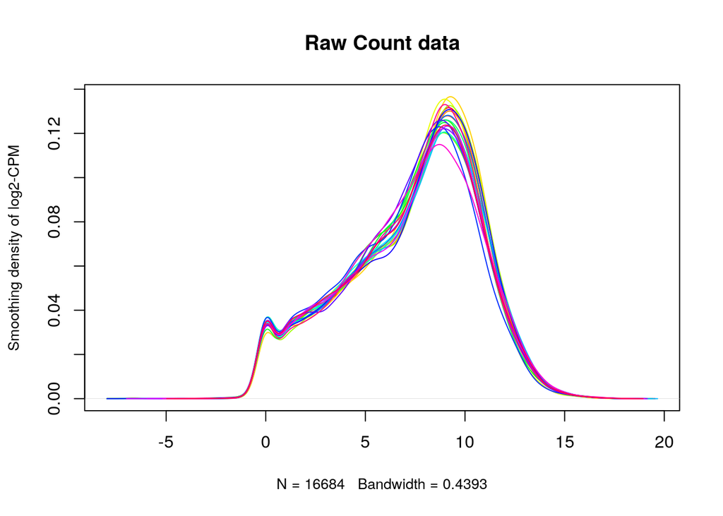

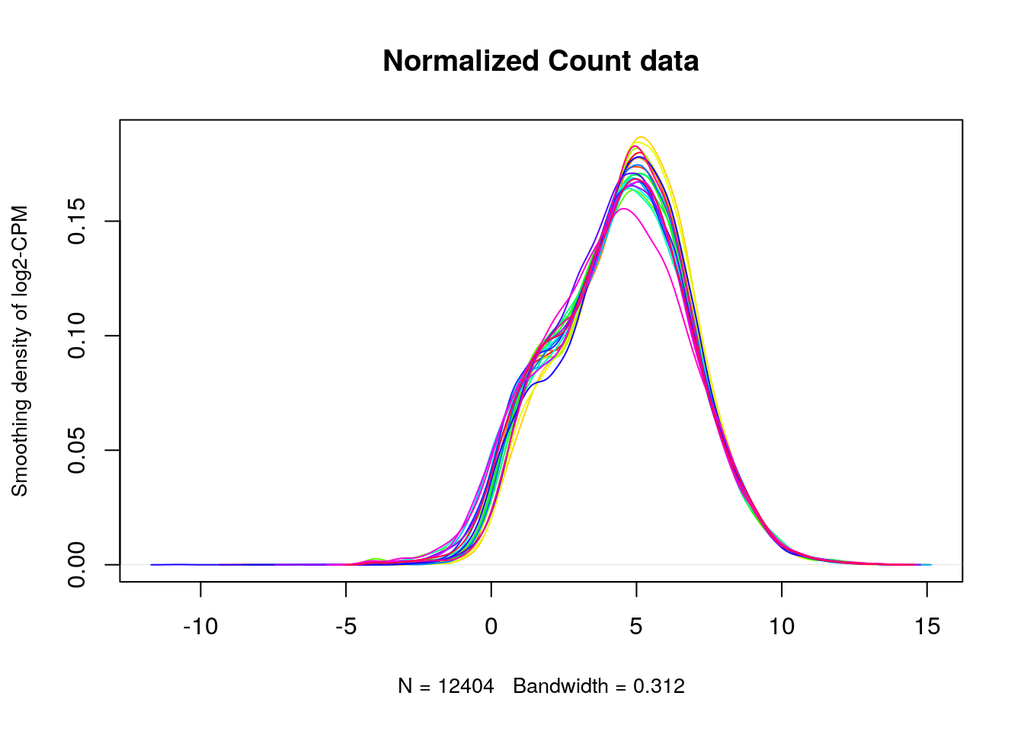

Density plot comparison of raw data and normalized data

```r
density_plot(TMM_norm_counts, 'Normalized Count data')
```

Next, we can see the changes using a multidimensional scaling plot

```r
limma::plotMDS(d, labels=NULL, pch = 1,
               col = c("darkgreen","red","blue")[factor(conditions)])
```

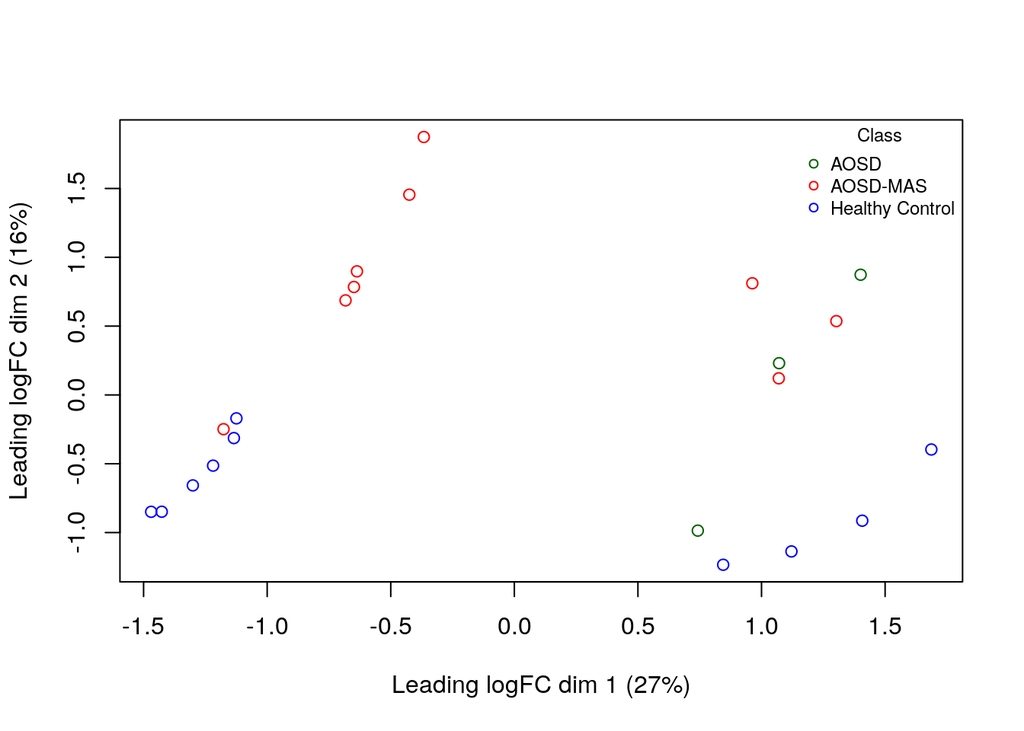

MSD plot

```r
legend("topright",
       legend=levels(factor(conditions)),
       pch=c(1), col = c("darkgreen","red","blue"),title = "Class", bty = 'n', cex = 0.75)
```

From the dataset, we can see that there is some separation between the samples from different conditions which is good.

Next, we can take a look at the dispersion among samples

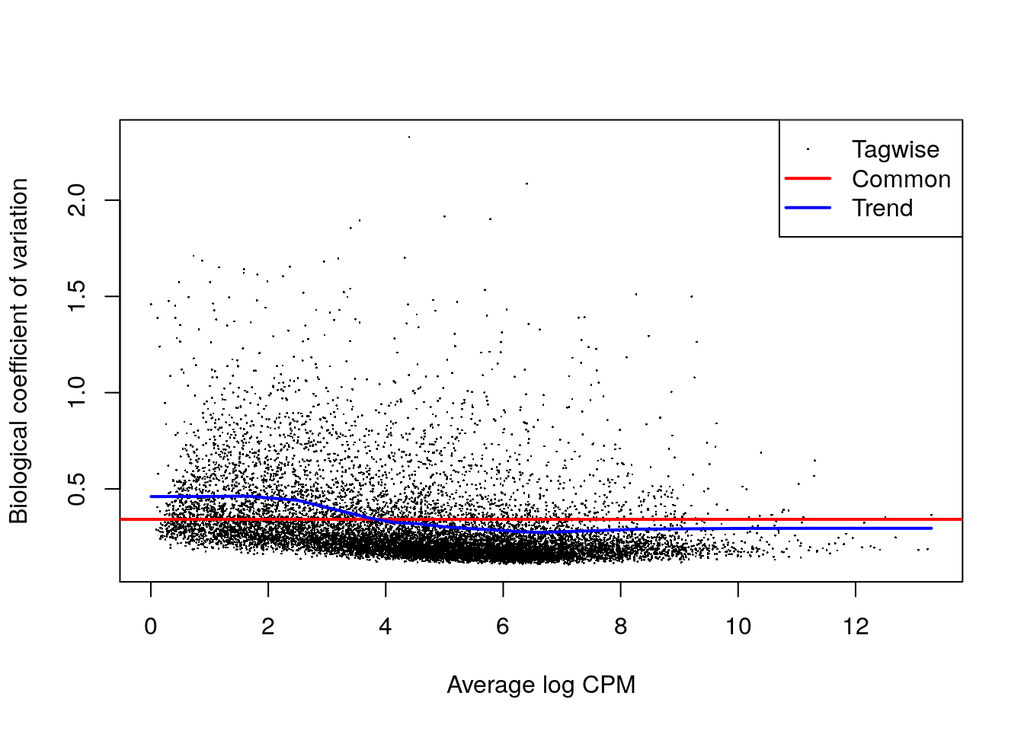

BCV plot

```r
disp <- model.matrix(~conditions)
est_d <- estimateDisp(d, disp)
plotBCV(est_d, col.tagwise = "black", col.common = "red")
```

Lastly, lets see the Mean-variance analysis

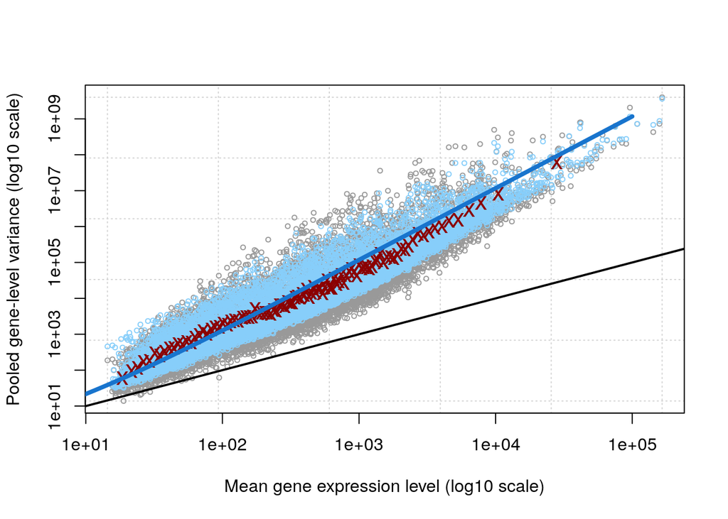

Mean-variance analysis

```r
plotMeanVar(est_d, show.raw.vars = TRUE, show.tagwise.vars=TRUE,
            NBline = TRUE, show.ave.raw.vars = TRUE,
            show.binned.common.disp.vars = FALSE)
```

The plot above shows that the data does follow a negative binomial distribution (blue line)

# Write out the normalized filtered data

```r
write.table(TMM_norm_counts, file.path(getwd(), dataset_geoid, paste(dataset_geoid, "TMM_normalized_filtered_RSEM_counts.txt",sep="_")),
            quote = FALSE, sep = "\t", row.names = TRUE)
```

# Interpretation

## Q1. What are the control and test conditions of the dataset?

[output not shown]

## Q2. Why is the dataset of interest to you?

```
This dataset was interesting to me because im interested in arthritis research, thus, I found out that the disease AOSD is characterized by multiple symptoms, one of which is arthritis.

More can be read in my journal entry on [github](https://github.com/bcb420-2024/Isabel_Li/wiki/3.-Choosing-a-dataset-(Assignment-1))
```

## Q3. Were there expression values that were not unique for specific genes? How did you handle these?

[output not shown]

## Q4. Were there expression values that could not be mapped to current HUGO symbols?

```
Yes, there were expression values that could not be mapped to HUGO symbols. After manually checking, I found that indeed, there was no HUGO symbol associated with those genes.
```

## Q5. How many outliers were removed?

[output not shown]

## Q6. How did you handle replicates?

```
I treated replicates as a either one of the conditions which is either the healthy control, AOSD-MAS or AOSD.
```

## Q7. What is the final coverage of your dataset?

```
The final coverage of the dataset is 12404
```

# References

1. Morgan M, Ramos M. [BiocManager: Access the bioconductor project package repository](https://CRAN.R-project.org/package=BiocManager). 2023.

2. Zhu H. [kableExtra: Construct complex table with ’kable’ and pipe syntax](http://haozhu233.github.io/kableExtra/). 2024.

3. Wickham H, François R, Henry L, Müller K, Vaughan D. [Dplyr: A grammar of data manipulation](https://CRAN.R-project.org/package=dplyr). 2023.

4. Chen Y, Chen L, Lun AAT, Baldoni P, Smyth GK. edgeR 4.0: Powerful differential analysis of sequencing data with expanded functionality and improved support for small counts and larger datasets. bioRxiv. 2024. https://doi.org/10.1101/2024.01.21.576131.

5. Wickham H. [ggplot2: Elegant graphics for data analysis](https://ggplot2.tidyverse.org). Springer-Verlag New York; 2016.

6. Hu Q, Jia J, Wang M. [Monocyte gene expression in adult-onset still’s disease](https://www.ncbi.nlm.nih.gov/geo/query/acc.cgi?acc=GSE247993). 2023.

7. Jia J, Wang M, Ma Y, Meng J, Zhu D, Chen X, et al. [Neutrophil extracellular trap-induced intermediate monocytes trigger macrophage activation syndrome in adult-onset still’s disease](https://doi.org/10.1186/s12916-023-03231-9). BMC Medicine. 2023;21.